# Overfitting Analysis Mclust

Renato Frey - renato.frey@unibas.ch

10 April, 2019

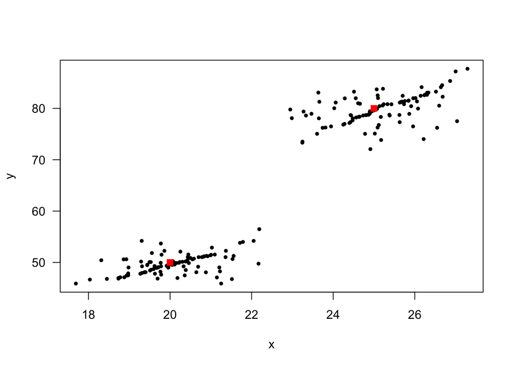

```r
## generate 2d-dataset with two obvious clusters
set.seed(123)

m_x1 <- 20
m_x2 <- 25
m_y1 <- 50
m_y2 <- 80
means <- data.frame(x=c(m_x1, m_x2), y=c(m_y1, m_y2))

x1 <- sort(rnorm(100, mean=m_x1, sd=1))
y1 <- sort(rnorm(100, mean=m_y1, sd=2))
ind1 <- sample(1:100, 50)
ind2 <- sample(1:100, 50)
y1[ind1] <- y1[ind2]

x2 <- sort(rnorm(100, mean=m_x2, sd=1))
y2 <- sort(rnorm(100, mean=m_y2, sd=3))
ind3 <- sample(1:100, 50)
ind4 <- sample(1:100, 50)
y2[ind3] <- y2[ind4]

x <- c(x1, x2)
y <- c(y1, y2)
d <- cbind(x,y)
plot(d, las=1, pch=16, cex=.7)
points(means, pch=15, cex=1.2, col="red")
```

```r
## use Mclust to fit three different GMMs
library(mclust)
# Model 1: This model overfits and the spurious clusters cannot be identified later on
model <- Mclust(d, G=1:10)

# Model 2: This model also overfits but the spurious clusters can later be identified
# model <- Mclust(d, G=1:10, modelNames=c("EEE"))

# Model 3: This would be the preferred model
# model <- Mclust(d, G=1:10, modelNames=c("EEV"))

# save the cluster means
c_means <- t(summary(model)$mean)

summary(model)
```

```
## ----------------------------------------------------
## Gaussian finite mixture model fitted by EM algorithm
## ----------------------------------------------------
##
## Mclust VVV (ellipsoidal, varying volume, shape, and orientation) model
## with 6 components:
##
##  log-likelihood   n df       BIC       ICL
##       -732.5609 200 35 -1650.563 -1680.362
##
## Clustering table:
##  1  2  3  4  5  6
## 44 46 10 19 56 25
```

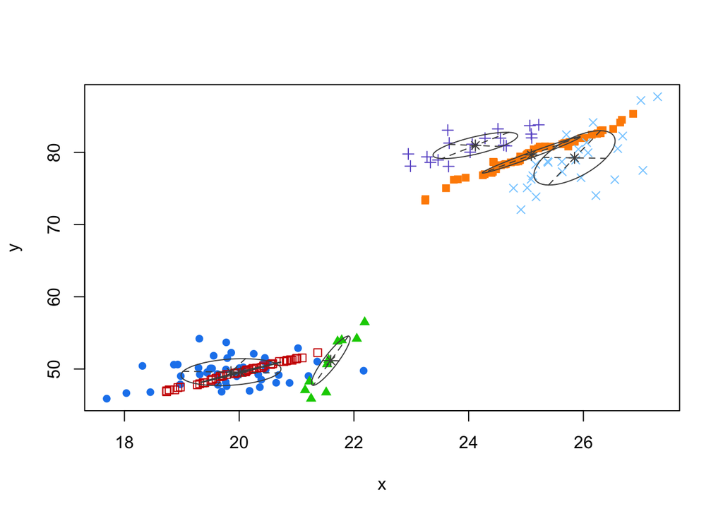

```r
plot(model, what="classification")
```

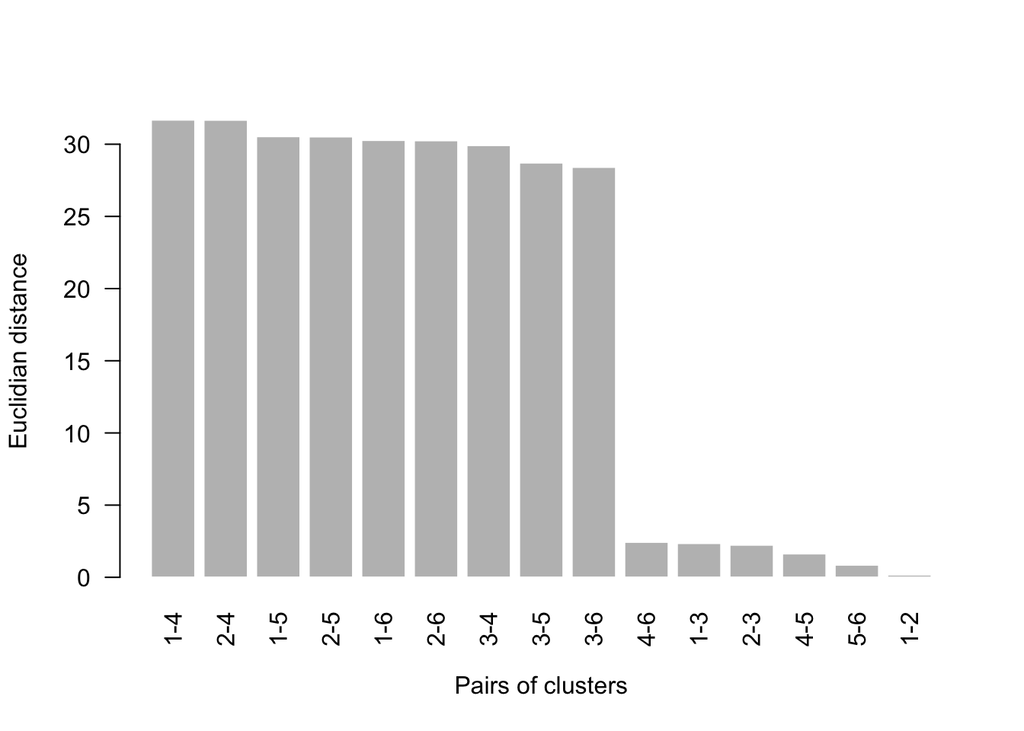

```r
# get euclidean distances between cluster means
dist <- dist(c_means, method = "euclidean", diag = F, upper = F)
dist_mat <- as.matrix(dist, diag=T, upper=T)
dists <- NULL
for (i in 1:(ncol(dist_mat)-1)) {
  for (j in (i+1):nrow(dist_mat)) {
    dists <- rbind(dists, data.frame("C1" = i, "C2" = j, "d" = dist_mat[i,j]))
  }
}
dists <- dists[order(dists$d, decreasing=T),]

# plot distances between cluster means (if more than 2 clusters)
if (nrow(c_means) > 2) barplot(dists$d, las=2, border=0, xlab="Pairs of clusters", ylab="Euclidian distance", names=paste(dists$C1, dists$C2, sep="-"))
```

For models 1 and 2, the analysis above shows that several cluster means are very close to each other (small euclidean distance between cluster means). For model 1, some clusters have almost the same means and the analysis below fails to identify that some of these clusters might be spurious. For model 2, some clusters are still somewhat close together, but the analysis below can identify that these clusters are spurious.

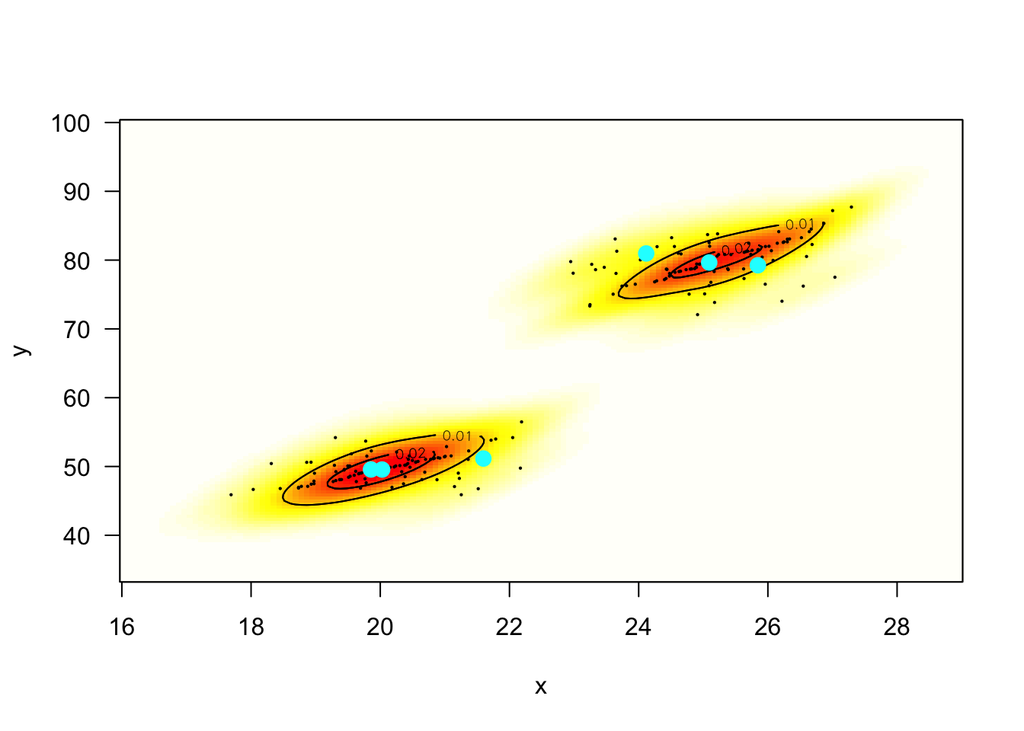

```r
## now use a Gaussian kernel to estimate the empirical density in the dataset
library(ks)
dens <- kde(d, binned=F)

# save the points where the density was evaluated (will be needed below)
evalp <- expand.grid(dens$eval.points[[1]], dens$eval.points[[2]])
colnames(evalp) <- c("x", "y")

# predict the density at the cluster means
dens_c_means <- predict(dens, x=c_means)

# plot the empirical density and add the cluster means
plot(dens, display="image", las=1)
points(d, pch=16, cex=0.3, col="black")
myconts <- round(seq(0.0001, max(dens$estimate), length.out=8), 2)
plot(dens, col="black", add=T, abs.cont=myconts)
points(c_means, col="cyan", pch=16, cex=1.5)
```

```r
## now generate a null-model to estimate the "saturation" of the identified clusters: specifically, 1) shuffle the dataset 100 times (by column, that is, keeping the marginal distributions (of each variable) constant, but removing any clusters) and 2) estimate the density in each of the shuffled datasets

null_model <- NULL
null_model_z <- NULL
for (i in 1:100) {

  # shuffle dataset
  d_shf <- apply(d, 2, sample)

  # estimate density
  dens_shf <- kde(d_shf, binned=F)

  # get (and store) the density at the cluster centers
  shf_c_means <- predict(dens_shf, x=c_means)
  null_model <- rbind(null_model, shf_c_means)

  # get (and store) the density at each actual datapoint
  shf_z <- predict(dens_shf, x=evalp)
  null_model_z <- rbind(null_model_z, shf_z)
}

# now determine a "non-parametric" p-value for each cluster, that is, the proportion of simulation runs in which the density at the cluster centers were LARGER (under the null-model) than the density of the clusters centers in the actual dataset
pvals <- rowMeans(apply(null_model, 1, function(x) {x > dens_c_means}))
print(pvals)
```

```
## [1] 0.00 0.00 0.00 0.07 0.00 0.00
```

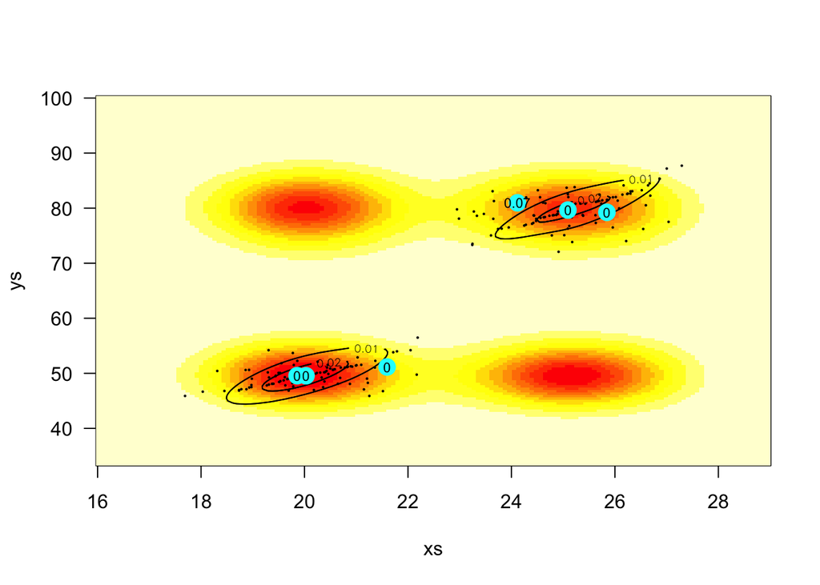

```r
# now obtain the average density across all the shuffled datasets (i.e., the null-model)
tmp <- colMeans(null_model_z)
xs <- unique(evalp$x)
ys <- unique(evalp$y)
out <- as.data.frame(matrix(NA, nrow=length(xs), ncol=length(ys)))
rownames(out) <- xs
colnames(out) <- ys
for (k in 1:length(tmp)) {
  out[as.character(evalp$x[k]), as.character(evalp$y[k])] <- tmp[k]
}

# plot the average density (under the assumption that there are no clusters in the dataset) and add the p-values to each of the cluster means
image(x=xs, y=ys, z=1-as.matrix(out), las=1)
points(d, pch=16, cex=0.3, col="black")
plot(dens, col="black", add=T, abs.cont=myconts)
points(c_means, col="cyan", pch=16, cex=2)
text(round(pvals, 2), x=c_means[,1], y=c_means[,2], cex=.7)
```

As outlined above, for model 1 this saturation analysis does not recognize that there exist several spurious clusters, because most of them happen to have means right at the peaks of the “empirical density”.

For model 2, this analysis works because some of the spurious clusters have means slightly outside the peaks of the empirical density, that is, where the density under the null-model peaks “higher” sufficiently often.

For model 3, the two cluster means are at the peaks of the empirical density, thus correctly resulting in very small p-values.